# Retail Pulse Kerala

Business Analytics and Documentation Report

Retail Analytics Team

2026-11-24

# Chapter 1: Executive Sales Performance Report

## 1.1 Business Problem

Retail managers need to understand overall sales performance, revenue generation, order activity, and sales trends.

This report evaluates the historical sales performance of Retail Pulse Kerala to support business planning and management decisions.

## 1.2 Dataset Description

The analysis uses the cleaned retail sales dataset containing 985,151 records.

Important fields include invoice details, invoice dates, product codes, quantities, and revenue.

## 1.3 Methodology

The analysis includes: - Data cleaning and validation. - Revenue and quantity calculations. - Order and customer KPI analysis. - Monthly revenue analysis. - Sales trend visualization.

## 1.4 Analysis and Visualizations

### Sales KPI Summary

```
##
##  Overall Sales KPI Summary
##
##
## Table: Overall Sales KPI Summary
##
## | total_revenue| total_quantity| total_orders| avg_order_value|
## |-------------:|--------------:|------------:|---------------:|
## |      19148015|       10936372|        38975|        491.2897|
```

```
##
##  Phase 4 KPI Results
##
##
## Table: Phase 4 KPI Results
##
## |kpi                                       |       value|
## |:-----------------------------------------|-----------:|
## |Total revenue (GBP)                       | 19148014.53|
## |Total orders                              |    38975.00|
## |Average order value (GBP)                 |      491.29|
## |Average selling price (GBP per unit)      |        1.75|
## |Revenue covered by cost data (%)          |       28.35|
## |Gross profit, covered products (GBP)      |  1564907.33|
## |Gross profit margin, covered products (%) |       28.83|
## |Sales growth, Jan-Nov 2011 vs 2010 (%)    |        3.00|
## |Return rate (%)                           |        3.52|
## |Customer retention 2010 to 2011 (%)       |       62.85|
```

### Monthly Revenue

```
##
##  Monthly Sales Summary
##
##
## Table: Monthly Sales Summary
##
## |month   | monthly_revenue| total_quantity|
## |:-------|---------------:|--------------:|
## |2009-12 |        798118.5|         425226|
## |2010-01 |        612365.5|         390417|
## |2010-02 |        537926.7|         381627|
## |2010-03 |        761748.5|         525046|
## |2010-04 |        646451.6|         366072|
## |2010-05 |        643585.6|         395442|
## |2010-06 |        696651.3|         406240|
## |2010-07 |        633079.4|         337560|
## |2010-08 |        674192.9|         471939|
## |2010-09 |        869277.2|         583369|
```

```
##
##  Monthly Revenue Trend
```

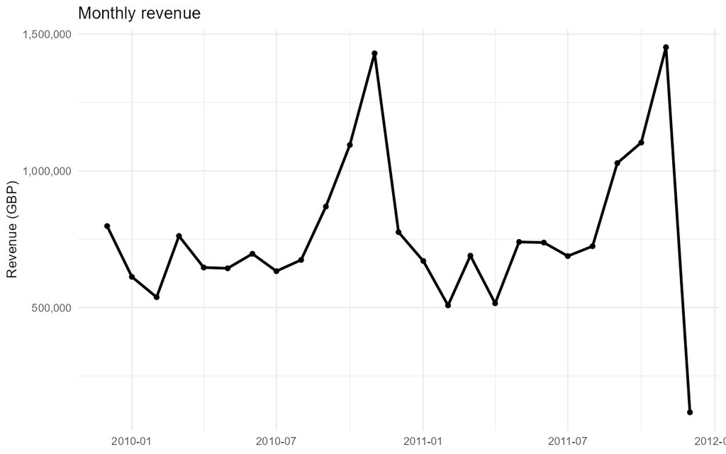

```
##
##  Month-on-Month Growth
```

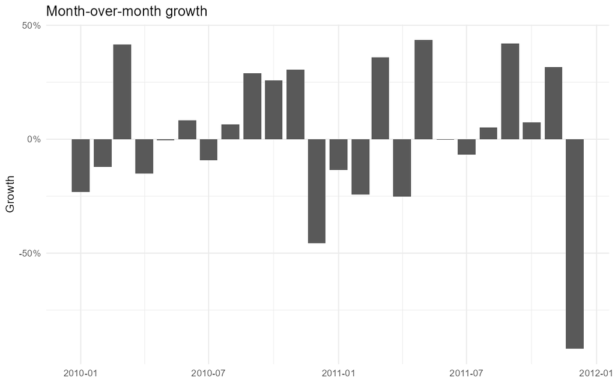

```
##
##  Weekly Revenue
```

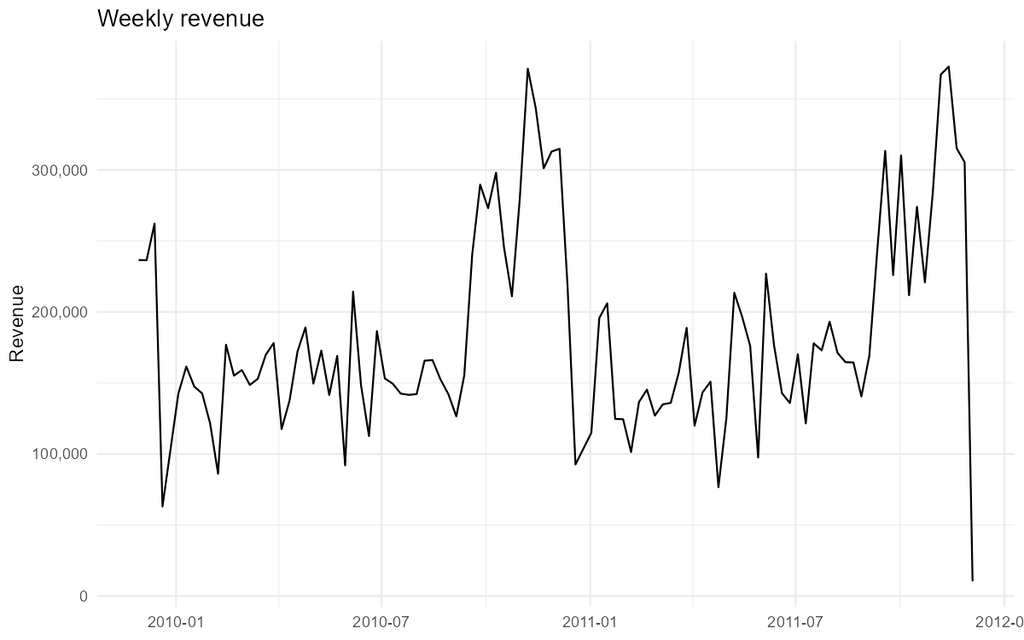

### Product and Category Performance

```
##
##  Top 10 Products
```

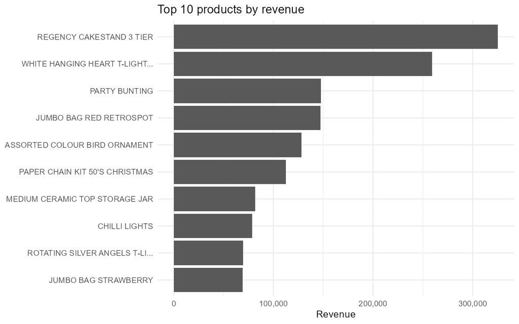

```
##
##  Category Revenue Distribution
```

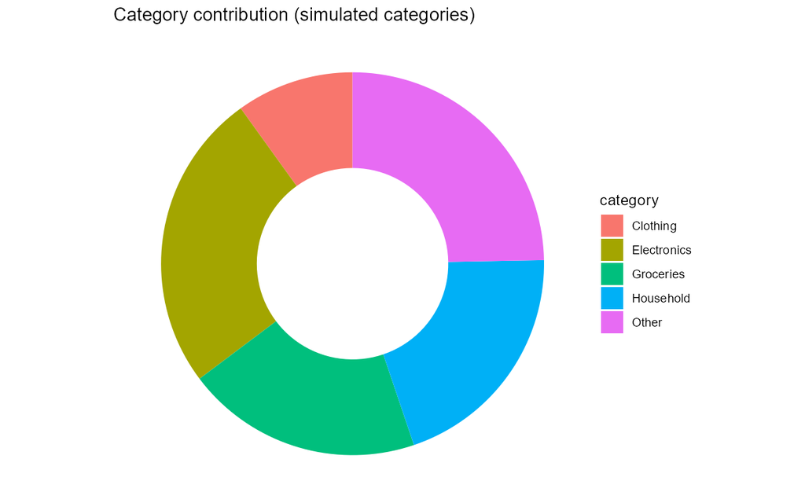

```
##
##  Product Profitability
##
##
## Table: Product Profitability
##
## |stock_code |description                 |  revenue| gross_profit| margin_pct|
## |:----------|:---------------------------|--------:|------------:|----------:|
## |15036      |ASSORTED COLOURS SILK FAN   | 32944.21|     12142.95|  36.859133|
## |15056BL    |EDWARDIAN PARASOL BLACK     | 48225.44|      3650.29|   7.569221|
## |15056N     |EDWARDIAN PARASOL NATURAL   | 59734.18|     18722.98|  31.343830|
## |20685      |DOOR MAT RED SPOT           | 15889.75|      -511.25|  -3.217483|
## |20685      |DOORMAT RED RETROSPOT       | 34709.25|      1874.25|   5.399857|
## |20685      |DOORMAT RED SPOT            |  7765.42|       597.82|   7.698489|
## |20685      |RED SPOTTY COIR DOORMAT     |  7563.34|      -185.06|  -2.446803|
## |20712      |JUMBO BAG WOODLAND ANIMALS  | 37122.37|     14971.57|  40.330318|
## |20713      |JUMBO BAG OWLS              | 40146.81|     11120.55|  27.699710|
## |20724      |RED RETROSPOT CHARLOTTE BAG | 23822.15|     10444.93|  43.845455|
```

## 1.5 Key Findings

The completed KPI analysis recorded: - Total revenue: GBP 19,148,015. - Total orders: 38,975. - Average order value: GBP 491. - Average selling price: GBP 1.75 per unit. - Sales growth from January to November 2011 compared with the same period in 2010: 3%.

These are historical results from the project analysis.

## 1.6 Business Implications

Sales KPIs help managers understand revenue generation and purchasing activity. Monthly trends help identify periods of stronger or weaker performance.

## 1.7 Recommendations

- Monitor revenue and order KPIs regularly.
- Identify products contributing the most revenue.
- Investigate declining sales periods.
- Use historical sales trends for business planning.
- Review product profitability before making pricing decisions.

## 1.8 Limitations

- Historical sales do not guarantee future performance.
- Some customer information is missing.
- Cost information is available for only a portion of products.

# Chapter 2: Customer Segmentation Report

## 2.1 Business Problem

Customers have different purchasing patterns and values. Understanding these differences helps retailers improve customer retention, loyalty, and marketing strategies.

## 2.2 Dataset Description

This analysis uses customer analytics outputs, including high-value customer information, churn predictions, customer segmentation visualizations, and reactivation recommendations.

## 2.3 Methodology

The project uses customer purchasing behaviour, RFM-related analysis, customer value evaluation, and churn modelling.

## 2.4 Analysis and Visualizations

### Customer Segmentation

```
##
##  Customer Segmentation
```

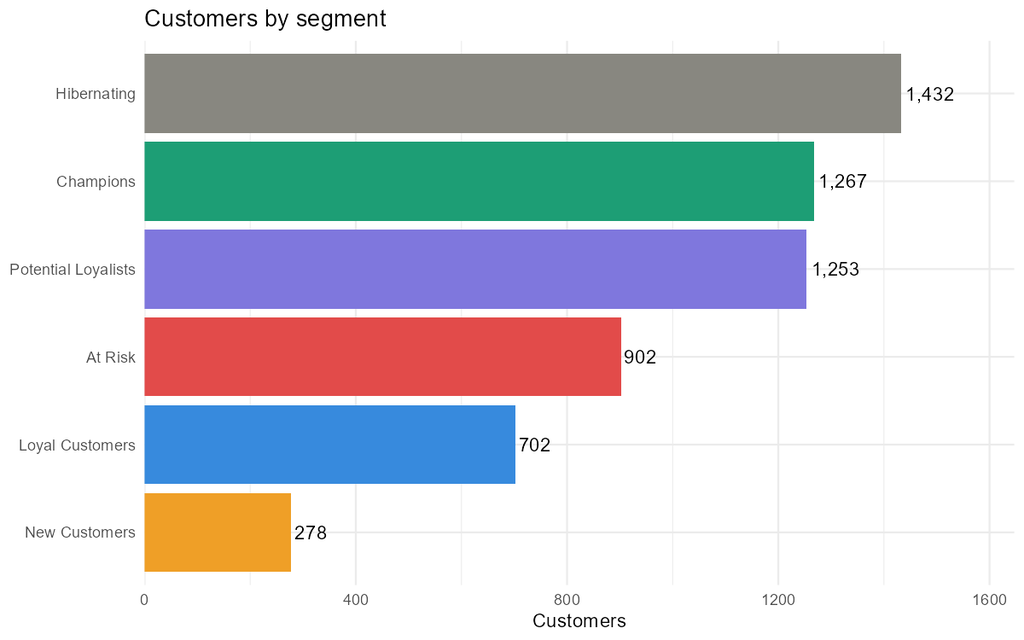

```
##
##  Customer Segment Comparison
```

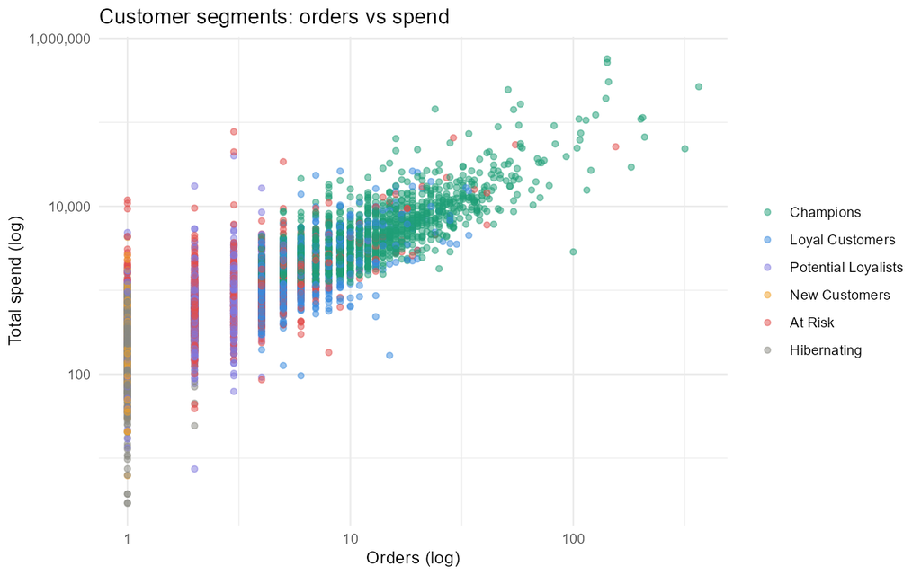

```
##
##  Customer Recency Distribution
```

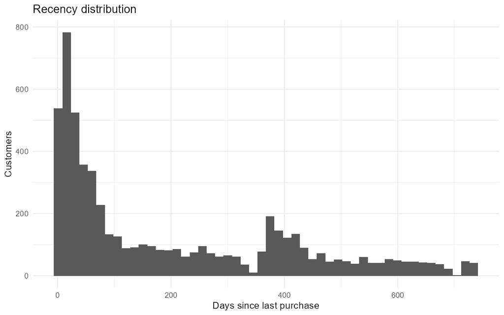

### High-Value Customers

```
##
##  High-Value Customer Records
##
##
## Table: High-Value Customer Records
##
## | customer_id|segment   | recency| frequency| monetary|
## |-----------:|:---------|-------:|---------:|--------:|
## |       18102|Champions |       7|       142| 569501.5|
## |       14646|Champions |      12|       142| 515023.5|
## |       14156|Champions |       5|       144| 303069.9|
## |       14911|Champions |       4|       366| 266000.8|
## |       17450|Champions |       4|        51| 244784.2|
## |       13694|Champions |      21|       140| 192509.5|
## |       17511|Champions |      12|        58| 164753.5|
## |       12415|Champions |      20|        24| 144033.4|
## |       16684|Champions |       7|        54| 141740.8|
## |       15061|Champions |       6|       126| 122491.7|
```

### Churn Analysis

```
##
##  Churn Model Comparison
##
##
## Table: Churn Model Comparison
##
## |model               | precision| recall|    f1| roc_auc| accuracy|   TP|   FP|  FN|  TN|
## |:-------------------|---------:|------:|-----:|-------:|--------:|----:|----:|---:|---:|
## |Logistic regression |     0.681|  0.928| 0.785|   0.796|    0.711| 2777| 1300| 217| 949|
## |Random forest       |     0.686|  0.922| 0.787|   0.777|    0.714| 2759| 1262| 235| 987|
```

```
##
##  Churn Feature Importance
##
##
## Table: Churn Feature Importance
##
## |feature             | importance|
## |:-------------------|----------:|
## |days_between_orders |  285.19863|
## |recency             |  227.97014|
## |monetary            |  214.70004|
## |spend_last90        |  209.38114|
## |n_products          |  157.92017|
## |avg_order_value     |  157.49395|
## |frequency           |  147.37490|
## |tenure              |  143.67283|
## |orders_last90       |  120.65576|
## |recent_share        |   59.48702|
```

```
##
##  Churn Model Feature Importance
```

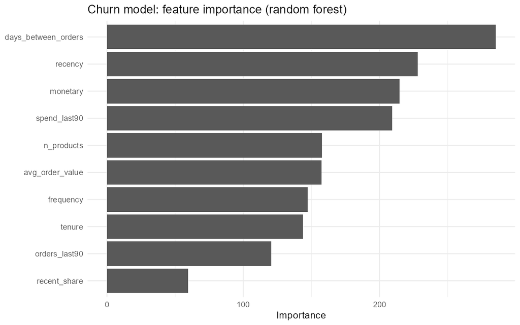

### Customer Reactivation

```
##
##  Customer Reactivation Recommendations
##
##
## Table: Customer Reactivation Recommendations
##
## | customer_id|priority | recency| frequency| monetary|favourite_product                  |favourite_category | offer_pct|recommendation                                                                                 |
## |-----------:|:--------|-------:|---------:|--------:|:----------------------------------|:------------------|---------:|:----------------------------------------------------------------------------------------------|
## |       12346|High     |     321|         3| 77352.96|MEDIUM CERAMIC TOP STORAGE JAR     |n/a                |        15|Send a 15% win-back offer on 'MEDIUM CERAMIC TOP STORAGE JAR'. Last purchase 321 days ago.     |
## |       16754|High     |     368|        29| 65500.07|RED HARMONICA IN BOX               |n/a                |        15|Send a 15% win-back offer on 'RED HARMONICA IN BOX'. Last purchase 368 days ago.               |
## |       13093|High     |     271|        55| 54144.25|REGENCY CAKESTAND 3 TIER           |n/a                |        15|Send a 15% win-back offer on 'REGENCY CAKESTAND 3 TIER'. Last purchase 271 days ago.           |
## |       17850|High     |     368|       155| 51208.87|WOOD S/3 CABINET ANT WHITE FINISH  |n/a                |        15|Send a 15% win-back offer on 'WOOD S/3 CABINET ANT WHITE FINISH'. Last purchase 368 days ago.  |
## |       15749|High     |     231|         3| 44534.30|FAIRY CAKE FLANNEL ASSORTED COLOUR |n/a                |        15|Send a 15% win-back offer on 'FAIRY CAKE FLANNEL ASSORTED COLOUR'. Last purchase 231 days ago. |
## |       13902|High     |     628|         5| 34023.26|SMALL FAIRY CAKE FRIDGE MAGNETS    |n/a                |        15|Send a 15% win-back offer on 'SMALL FAIRY CAKE FRIDGE MAGNETS'. Last purchase 628 days ago.    |
## |       12482|High     |     572|        27| 21941.72|LUNCH BAG SUKI DESIGN              |n/a                |        15|Send a 15% win-back offer on 'LUNCH BAG SUKI DESIGN'. Last purchase 572 days ago.              |
## |       15808|High     |     302|        21| 17180.25|REGENCY CAKESTAND 3 TIER           |n/a                |        15|Send a 15% win-back offer on 'REGENCY CAKESTAND 3 TIER'. Last purchase 302 days ago.           |
## |       13564|High     |     350|        36| 15880.22|REGENCY CAKESTAND 3 TIER           |n/a                |        15|Send a 15% win-back offer on 'REGENCY CAKESTAND 3 TIER'. Last purchase 350 days ago.           |
## |       17448|High     |     525|        41| 14448.67|WHITE HANGING HEART T-LIGHT HOLDER |n/a                |        15|Send a 15% win-back offer on 'WHITE HANGING HEART T-LIGHT HOLDER'. Last purchase 525 days ago. |
```

```
##
##  Customer Churn Risk Predictions
##
##
## Table: Customer Churn Risk Predictions
##
## | customer_id|segment     | churn_risk|risk_band | recency| frequency| monetary|action                          |
## |-----------:|:-----------|----------:|:---------|-------:|---------:|--------:|:-------------------------------|
## |       14728|Hibernating |  0.9906586|High      |     409|         1|   190.58|Win-back email with a 10% offer |
## |       18208|Hibernating |  0.9903068|High      |     561|         1|   360.08|Win-back email with a 10% offer |
## |       14945|Hibernating |  0.9900525|High      |     409|         1|   179.40|Win-back email with a 10% offer |
## |       14278|Hibernating |  0.9899722|High      |     405|         1|   205.83|Win-back email with a 10% offer |
## |       13746|Hibernating |  0.9899055|High      |     409|         1|   176.69|Win-back email with a 10% offer |
## |       14325|Hibernating |  0.9896702|High      |     565|         1|   245.48|Win-back email with a 10% offer |
## |       15718|Hibernating |  0.9895541|High      |     536|         1|   293.79|Win-back email with a 10% offer |
## |       17202|Hibernating |  0.9894616|High      |     416|         1|   160.65|Win-back email with a 10% offer |
## |       16944|Hibernating |  0.9886950|High      |     605|         1|   101.36|Win-back email with a 10% offer |
## |       13903|Hibernating |  0.9885710|High      |     396|         1|   165.45|Win-back email with a 10% offer |
```

## 2.5 Key Findings

The project generates customer segmentation, high-value customer records, and churn-risk predictions.

These outputs can help identify customers who may need additional engagement. Actual segment sizes and model performance should be interpreted using the displayed results.

## 2.6 Business Implications

Customer segmentation allows management to develop different strategies for valuable, active, and potentially inactive customers.

## 2.7 Recommendations

- Introduce loyalty programmes for high-value customers.
- Develop reactivation campaigns for inactive customers.
- Monitor churn-risk predictions.
- Use customer purchasing behaviour for targeted marketing.
- Review customer segments regularly.

## 2.8 Limitations

- Missing customer identifiers can affect customer-level analysis.
- Historical customer behaviour may change.
- Churn predictions depend on data quality and model performance.

# Chapter 3: Inventory Optimization Report

## 3.1 Business Problem

Poor inventory management can cause stock shortages, excess inventory, and lost sales.

The purpose of this report is to evaluate inventory performance and support better stock replenishment decisions.

## 3.2 Dataset Description

The project uses product, inventory, sales, demand, supplier lead-time, and reorder recommendation outputs.

## 3.3 Methodology

The analysis includes: - Inventory KPI calculations. - Stock status evaluation. - Inventory risk identification. - Supplier lead-time analysis. - Reorder recommendation analysis.

## 3.4 Analysis and Visualizations

### Inventory KPIs and Risk

```
##
##  Inventory KPI Summary
##
##
## Table: Inventory KPI Summary
##
## |metric                                         |    value|
## |:----------------------------------------------|--------:|
## |Current inventory value (GBP, simulated stock) | 424440.0|
## |Product-store combinations                     |    500.0|
## |Critical stockouts                             |     17.0|
## |Replenishment needed                           |    101.0|
## |Low stock (under 7 days)                       |     35.0|
## |Overstocked (over 90 days)                     |    115.0|
## |Slow-moving                                    |      2.0|
## |Dead stock                                     |      0.0|
## |Overall inventory turnover (times per year)    |      6.0|
## |Average days of inventory remaining (median)   |     57.9|
```

```
##
##  Inventory Risk Details
##
##
## Table: Inventory Risk Details
##
## |store_id |product_id | avg_daily_demand|   sd_daily|last_sale  |product_name                      |category    | cost_price|supplier_id |supplier_name | lead_time|store_name        |district  | days_since_sale| stock_quantity| inventory_value| days_remaining|stockout_date | safety_stock| reorder…
## |:--------|:----------|----------------:|----------:|:----------|:---------------------------------|:-----------|----------:|:-----------|:-------------|---------:|:-----------------|:---------|---------------:|--------------:|---------------:|--------------:|:-------------|------------:|--------…
## |TSR01    |22189      |        4.0777778|  23.448355|2011-12-04 |CREAM HEART CARD HOLDER           |Household   |       3.15|SUP15       |Supplier 15   |        15|Thrissur Central  |Thrissur  |               0|              0|               0|              0|2011-12-04    |          150|        …
## |EKM01    |22178      |       22.1222222| 105.249071|2011-12-01 |VICTORIAN GLASS HANGING T-LIGHT   |Household   |       1.03|SUP1        |Supplier 1    |        11|Ernakulam Central |Ernakulam |               3|              0|               0|              0|2011-12-04    |          576|        …
## |EKM01    |22328      |        2.3888889|   5.085106|2011-12-01 |ROUND SNACK BOXES ,SET 4, FRUITS  |Groceries   |       1.94|SUP10       |Supplier 10   |        10|Ernakulam Central |Ernakulam |               3|              0|               0|              0|2011-12-04    |           27|        …
## |EKM01    |20726      |        4.4555556|   8.408344|2011-12-01 |LUNCH BAG WOODLAND                |Other       |       1.15|SUP6        |Supplier 6    |         5|Ernakulam Central |Ernakulam |               3|              0|               0|              0|2011-12-04    |           32|        …
## |EKM01    |22960      |        3.8111111|   6.775525|2011-12-02 |JAM MAKING SET WITH JARS          |Household   |       2.56|SUP15       |Supplier 15   |        15|Ernakulam Central |Ernakulam |               2|              0|               0|              0|2011-12-04    |           44|        …
## |KZD01    |21175      |        5.0111111|  21.431623|2011-12-02 |GIN + TONIC DIET METAL SIGN       |Groceries   |       1.46|SUP9        |Supplier 9    |        10|Kozhikode Main    |Kozhikode |               2|              0|               0|              0|2011-12-04    |          112|        …
## |KZD01    |82486      |        0.9666667|   2.270722|2011-11-29 |WOOD S/3 CABINET ANT WHITE FINISH |Other       |       6.50|SUP12       |Supplier 12   |         6|Kozhikode Main    |Kozhikode |               5|              0|               0|              0|2011-12-04    |           10|        …
## |KZD01    |22382      |        4.7000000|   6.654305|2011-11-30 |LUNCHBAG SPACEBOY DESIGN          |Clothing    |       1.34|SUP6        |Supplier 6    |         5|Kozhikode Main    |Kozhikode |               4|              0|               0|              0|2011-12-04    |           25|        …
## |TSR01    |21843      |        0.4555556|   1.153023|2011-12-01 |RETRO SPOT CAKE STAND             |Clothing    |       8.00|SUP13       |Supplier 13   |         8|Thrissur Central  |Thrissur  |               3|              0|               0|              0|2011-12-04    |            6|        …
## |TSR01    |22910      |       17.4000000|  28.540450|2011-12-04 |PAPER CHAIN KIT VINTAGE CHRISTMAS |Electronics |       1.99|SUP7        |Supplier 7    |        14|Thrissur Central  |Thrissur  |               0|              0|               0|              0|2011-12-04    |          177|        …
```

```
##
##  Inventory Status
```

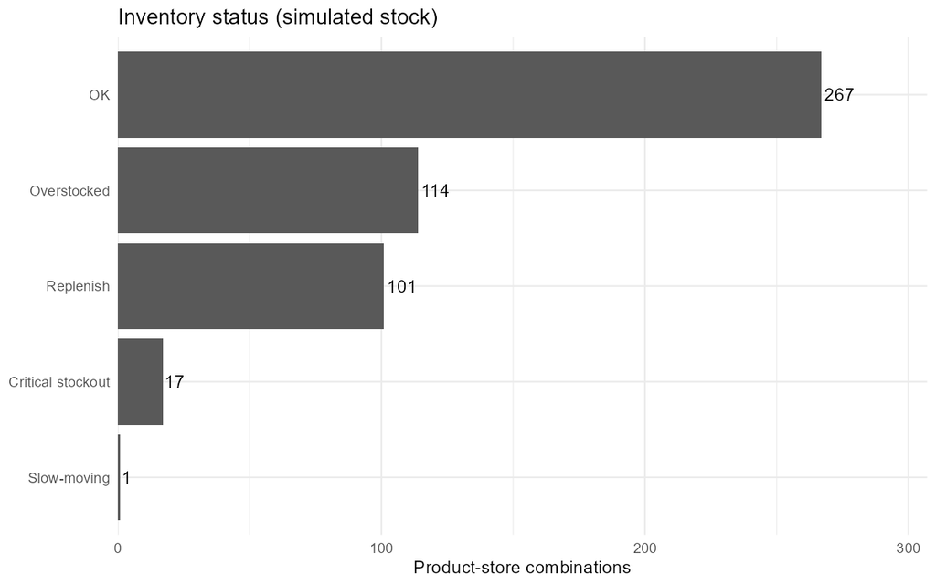

```
##
##  Highest Inventory Risks
```

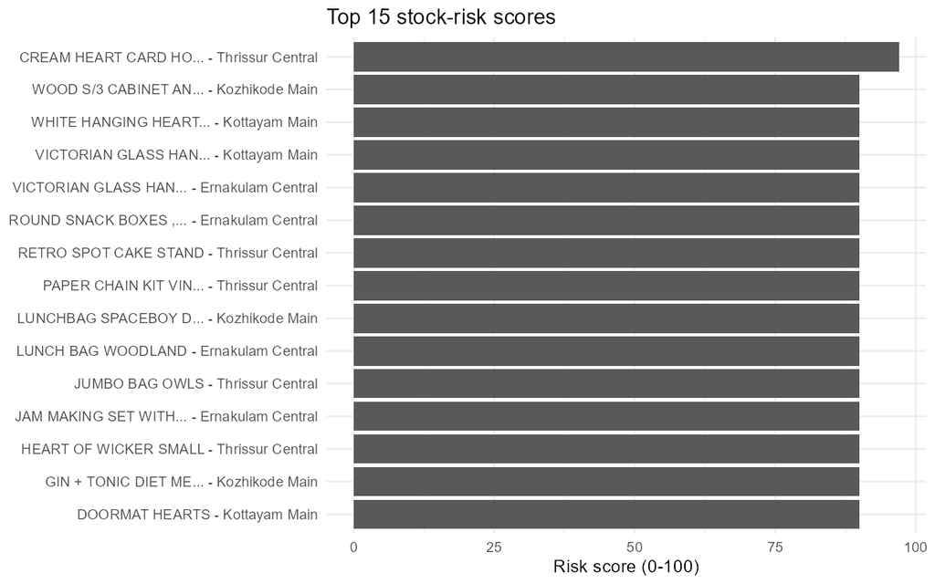

### Stock and Supplier Analysis

```
##
##  Estimated Days of Stock Remaining
```

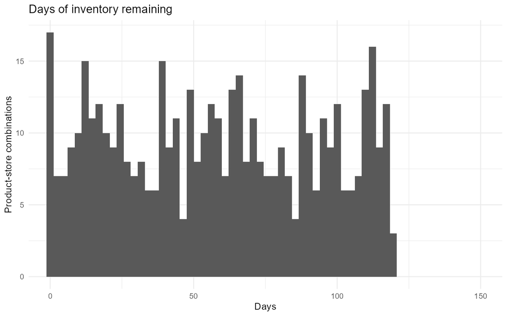

```
##
##  Supplier Lead Times
```

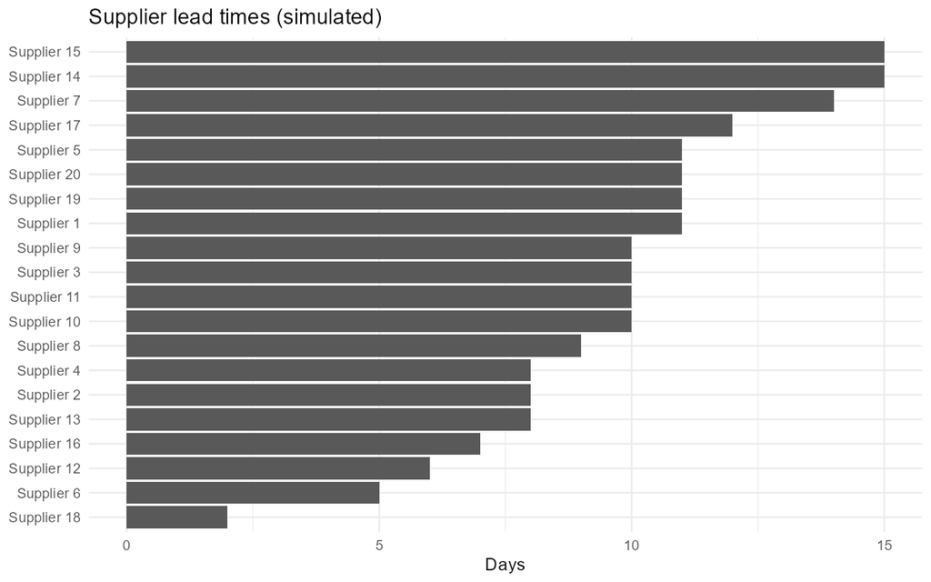

### Reorder Recommendations

```
##
##  Reorder Recommendations
##
##
## Table: Reorder Recommendations
##
## |priority | risk_score|store_name        |district  |product_id |product_name                      |status            | stock_quantity| avg_daily_demand| days_remaining| lead_time| reorder_point| reorder_qty|stockout_date |supplier_name |recommendation                                             …
## |:--------|----------:|:-----------------|:---------|:----------|:---------------------------------|:-----------------|--------------:|----------------:|--------------:|---------:|-------------:|-----------:|:-------------|:-------------|:----------------------------------------------------------…
## |Critical |         97|Thrissur Central  |Thrissur  |22189      |CREAM HEART CARD HOLDER           |Critical stockout |              0|        4.0777778|              0|        15|           212|         269|2011-12-04    |Supplier 15   |Order 269 units of CREAM HEART CARD HOLDER for Thrissur Cen…
## |Critical |         90|Ernakulam Central |Ernakulam |22178      |VICTORIAN GLASS HANGING T-LIGHT   |Critical stockout |              0|       22.1222222|              0|        11|           820|        1130|2011-12-04    |Supplier 1    |Order 1130 units of VICTORIAN GLASS HANGING T-LIGHT for Ern…
## |Critical |         90|Ernakulam Central |Ernakulam |22328      |ROUND SNACK BOXES ,SET 4, FRUITS  |Critical stockout |              0|        2.3888889|              0|        10|            51|          85|2011-12-04    |Supplier 10   |Order 85 units of ROUND SNACK BOXES ,SET 4, FRUITS for Erna…
## |Critical |         90|Ernakulam Central |Ernakulam |20726      |LUNCH BAG WOODLAND                |Critical stockout |              0|        4.4555556|              0|         5|            55|         117|2011-12-04    |Supplier 6    |Order 117 units of LUNCH BAG WOODLAND for Ernakulam Central…
## |Critical |         90|Ernakulam Central |Ernakulam |22960      |JAM MAKING SET WITH JARS          |Critical stockout |              0|        3.8111111|              0|        15|           102|         155|2011-12-04    |Supplier 15   |Order 155 units of JAM MAKING SET WITH JARS for Ernakulam C…
## |Critical |         90|Kozhikode Main    |Kozhikode |21175      |GIN + TONIC DIET METAL SIGN       |Critical stockout |              0|        5.0111111|              0|        10|           163|         233|2011-12-04    |Supplier 9    |Order 233 units of GIN + TONIC DIET METAL SIGN for Kozhikod…
## |Critical |         90|Kozhikode Main    |Kozhikode |82486      |WOOD S/3 CABINET ANT WHITE FINISH |Critical stockout |              0|        0.9666667|              0|         6|            16|          30|2011-12-04    |Supplier 12   |Order 30 units of WOOD S/3 CABINET ANT WHITE FINISH for Koz…
## |Critical |         90|Kozhikode Main    |Kozhikode |22382      |LUNCHBAG SPACEBOY DESIGN          |Critical stockout |              0|        4.7000000|              0|         5|            49|         115|2011-12-04    |Supplier 6    |Order 115 units of LUNCHBAG SPACEBOY DESIGN for Kozhikode M…
## |Critical |         90|Thrissur Central  |Thrissur  |21843      |RETRO SPOT CAKE STAND             |Critical stockout |              0|        0.4555556|              0|         8|            10|          17|2011-12-04    |Supplier 13   |Order 17 units of RETRO SPOT CAKE STAND for Thrissur Centra…
## |Critical |         90|Thrissur Central  |Thrissur  |22910      |PAPER CHAIN KIT VINTAGE CHRISTMAS |Critical stockout |              0|       17.4000000|              0|        14|           421|         665|2011-12-04    |Supplier 7    |Order 665 units of PAPER CHAIN KIT VINTAGE CHRISTMAS for Th…
```

```
##
##  Forecast-Based Reorder Recommendations
##
##
## Table: Forecast-Based Reorder Recommendations
##
## |fc_priority |fc_status         |store_name        |district  |product_id |product_name                       | stock_quantity| fc_demand_cover| safety_stock| lead_time| fc_reorder_qty|supplier_name |recommendation                                                                                   …
## |:-----------|:-----------------|:-----------------|:---------|:----------|:----------------------------------|--------------:|---------------:|------------:|---------:|--------------:|:-------------|:------------------------------------------------------------------------------------------------…
## |Critical    |Critical stockout |Kottayam Main     |Kottayam  |85123A     |WHITE HANGING HEART T-LIGHT HOLDER |              0|        682.2171|          586|        10|           1269|Supplier 11   |Order 1269 units of WHITE HANGING HEART T-LIGHT HOLDER for Kottayam Main. Forecast demand is 682 …
## |Critical    |Critical stockout |Ernakulam Central |Ernakulam |22178      |VICTORIAN GLASS HANGING T-LIGHT    |              0|        547.5653|          576|        11|           1124|Supplier 1    |Order 1124 units of VICTORIAN GLASS HANGING T-LIGHT for Ernakulam Central. Forecast demand is 548…
## |Critical    |Critical stockout |Thrissur Central  |Thrissur  |22910      |PAPER CHAIN KIT VINTAGE CHRISTMAS  |              0|        467.6163|          177|        14|            645|Supplier 7    |Order 645 units of PAPER CHAIN KIT VINTAGE CHRISTMAS for Thrissur Central. Forecast demand is 468…
## |Critical    |Critical stockout |Kottayam Main     |Kottayam  |22178      |VICTORIAN GLASS HANGING T-LIGHT    |              0|        299.2220|          168|        11|            468|Supplier 1    |Order 468 units of VICTORIAN GLASS HANGING T-LIGHT for Kottayam Main. Forecast demand is 299 unit…
## |Critical    |Critical stockout |Thrissur Central  |Thrissur  |20713      |JUMBO BAG OWLS                     |              0|        176.0076|          133|         8|            310|Supplier 4    |Order 310 units of JUMBO BAG OWLS for Thrissur Central. Forecast demand is 176 units over the nex…
## |Critical    |Critical stockout |Thrissur Central  |Thrissur  |22189      |CREAM HEART CARD HOLDER            |              0|        114.5712|          150|        15|            265|Supplier 15   |Order 265 units of CREAM HEART CARD HOLDER for Thrissur Central. Forecast demand is 115 units ove…
## |Critical    |Critical stockout |Kozhikode Main    |Kozhikode |21175      |GIN + TONIC DIET METAL SIGN        |              0|        117.4351|          112|        10|            230|Supplier 9    |Order 230 units of GIN + TONIC DIET METAL SIGN for Kozhikode Main. Forecast demand is 117 units o…
## |Critical    |Critical stockout |Thrissur Central  |Thrissur  |22469      |HEART OF WICKER SMALL              |              0|        155.7122|           65|        10|            221|Supplier 9    |Order 221 units of HEART OF WICKER SMALL for Thrissur Central. Forecast demand is 156 units over …
## |Critical    |Critical stockout |Kottayam Main     |Kottayam  |22385      |JUMBO BAG SPACEBOY DESIGN          |              0|        115.5085|           66|        11|            182|Supplier 1    |Order 182 units of JUMBO BAG SPACEBOY DESIGN for Kottayam Main. Forecast demand is 116 units over…
## |Critical    |Critical stockout |Ernakulam Central |Ernakulam |22960      |JAM MAKING SET WITH JARS           |              0|        107.0788|           44|        15|            152|Supplier 15   |Order 152 units of JAM MAKING SET WITH JARS for Ernakulam Central. Forecast demand is 107 units o…
```

## 3.5 Key Findings

The inventory analysis generates stock-status information, inventory risk records, and reorder recommendations.

The results help identify products that may require replenishment or closer monitoring.

## 3.6 Business Implications

Inventory analysis helps managers reduce stock shortages, avoid unnecessary stock accumulation, and improve product availability.

## 3.7 Recommendations

- Monitor products with high inventory risk.
- Review reorder recommendations regularly.
- Consider supplier lead times when planning purchases.
- Maintain appropriate safety stock.
- Compare actual demand with inventory levels.

## 3.8 Limitations

- Inventory recommendations depend on the accuracy of stock records.
- Supplier lead times may change.
- Forecasted demand may differ from actual demand.

# Chapter 4: Demand Forecasting and Model Evaluation Report

## 4.1 Business Problem

Retailers need to estimate future product demand to plan stock levels, purchasing, and business operations.

This report evaluates historical demand patterns and forecasting model outputs.

## 4.2 Dataset Description

The analysis uses historical daily sales and demand-related features, model comparison outputs, forecast results, and product demand classifications.

## 4.3 Methodology

The forecasting workflow includes: - Historical demand analysis. - Time-series visualization. - Feature preparation. - Forecast model comparison. - Model evaluation. - Future demand estimation.

## 4.4 Analysis and Visualizations

### Demand Patterns

```
##
##  Daily Demand Data
##
##
## Table: Daily Demand Data
##
## |date       | units|  revenue|had_sales |
## |:----------|-----:|--------:|:---------|
## |2009-12-01 | 26070| 52438.61|TRUE      |
## |2009-12-02 | 31799| 61873.10|TRUE      |
## |2009-12-03 | 49219| 73059.78|TRUE      |
## |2009-12-04 | 21192| 39349.21|TRUE      |
## |2009-12-05 |  5119|  9803.05|TRUE      |
## |2009-12-06 | 11525| 24285.02|TRUE      |
## |2009-12-07 | 17936| 42957.47|TRUE      |
## |2009-12-08 | 23130| 48694.71|TRUE      |
## |2009-12-09 | 17835| 38870.31|TRUE      |
## |2009-12-10 | 23576| 42160.37|TRUE      |
```

```
##
##  Demand Decomposition
```

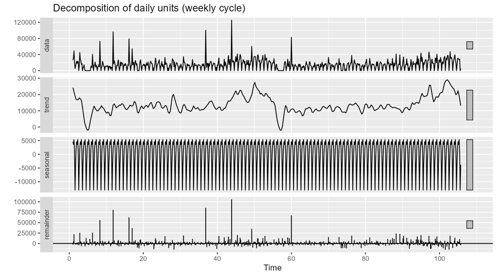

```
##
##  Weekly Demand
```

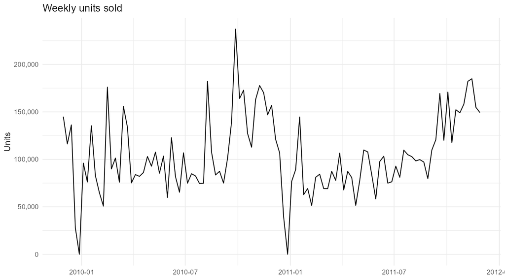

### Forecast Model Evaluation

```
##
##  Forecast Model Comparison
##
##
## Table: Forecast Model Comparison
##
## |model  | horizon|     MAE|    RMSE|    Bias| MAPE| rmse_vs_snaive_pct|
## |:------|-------:|-------:|-------:|-------:|----:|------------------:|
## |naive  |       7|  7882.0| 10077.0|  7882.0| 32.5|              -59.0|
## |naive  |      30|  9202.2| 11932.6|  2899.9| 37.5|               -2.1|
## |naive  |      90|  9677.9| 12185.1|  1428.9| 39.8|               -7.1|
## |snaive |       7|  5151.1|  6336.5|  -211.7| 34.1|                0.0|
## |snaive |      30|  7611.8| 11690.9| -5414.3| 34.8|                0.0|
## |snaive |      90|  8112.7| 11375.3| -6754.7| 36.7|                0.0|
## |ma7    |       7|  4391.2|  6282.1|  -211.7| 14.7|                0.9|
## |ma7    |      30|  9923.8| 12686.7| -5193.8| 35.4|               -8.5|
## |ma7    |      90| 11925.0| 13815.0| -6664.8| 44.9|              -21.4|
## |ets    |       7|  3439.1|  5018.0| -1010.6| 21.7|               20.8|
```

```
##
##  Best Model by Forecast Horizon
##
##
## Table: Best Model by Forecast Horizon
##
## |model         | horizon|    MAE|   RMSE|    Bias| MAPE| rmse_vs_snaive_pct|
## |:-------------|-------:|------:|------:|-------:|----:|------------------:|
## |random_forest |       7| 3799.0| 4730.3|  1226.2| 25.1|               25.3|
## |ets           |      30| 6789.5| 9856.4| -5748.7| 29.0|               15.7|
## |random_forest |      90| 5245.1| 8133.2|  -623.3| 31.6|               28.5|
```

```
##
##  Forecast Model Performance
```

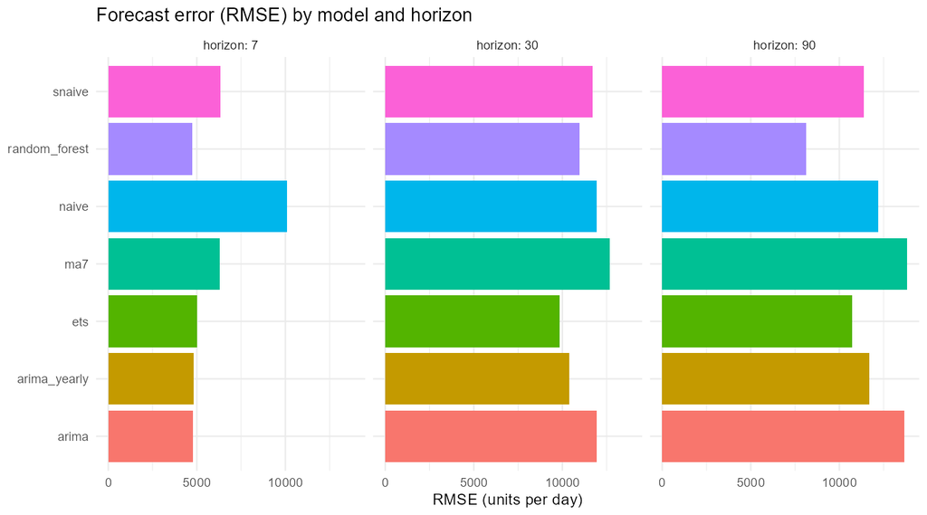

```
##
##  Actual versus Predicted Demand
```

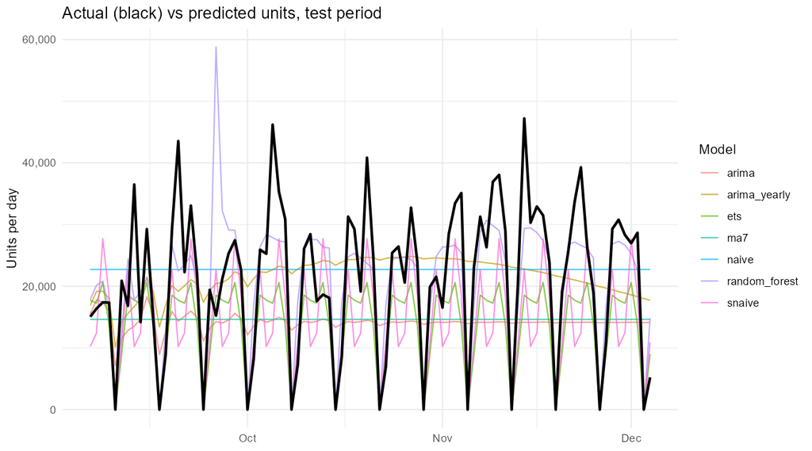

### Future Demand Forecast

```
##
##  Seven-Day Forecast
##
##
## Table: Seven-Day Forecast
##
## |date       | day_ahead|model         |     forecast|  lower_80|  upper_80|
## |:----------|---------:|:-------------|------------:|---------:|---------:|
## |2011-12-05 |         1|random_forest | 25031.756871| 18976.973| 31086.541|
## |2011-12-06 |         2|random_forest | 23994.161633| 17939.378| 30048.946|
## |2011-12-07 |         3|random_forest | 23923.264100| 17868.480| 29978.048|
## |2011-12-08 |         4|random_forest | 23064.414505| 17009.631| 29119.199|
## |2011-12-09 |         5|random_forest | 21750.474414| 15695.690| 27805.258|
## |2011-12-10 |         6|random_forest |     3.296761|     0.000|  6058.081|
## |2011-12-11 |         7|random_forest |  7083.318000|  1028.534| 13138.102|
```

```
##
##  Thirty-Day Forecast
##
##
## Table: Thirty-Day Forecast
##
## |date       | day_ahead|model         |     forecast|  lower_80|  upper_80|
## |:----------|---------:|:-------------|------------:|---------:|---------:|
## |2011-12-05 |         1|random_forest | 25031.756871| 18976.973| 31086.541|
## |2011-12-06 |         2|random_forest | 23994.161633| 17939.378| 30048.946|
## |2011-12-07 |         3|random_forest | 23923.264100| 17868.480| 29978.048|
## |2011-12-08 |         4|random_forest | 23064.414505| 17009.631| 29119.199|
## |2011-12-09 |         5|random_forest | 21750.474414| 15695.690| 27805.258|
## |2011-12-10 |         6|random_forest |     3.296761|     0.000|  6058.081|
## |2011-12-11 |         7|random_forest |  7083.318000|  1028.534| 13138.102|
## |2011-12-12 |         8|ets           | 26019.652660| 13403.461| 38635.845|
## |2011-12-13 |         9|ets           | 24896.214581| 12280.023| 37512.407|
## |2011-12-14 |        10|ets           | 24975.244588| 12359.053| 37591.437|
```

```
##
##  Ninety-Day Forecast
##
##
## Table: Ninety-Day Forecast
##
## |date       | day_ahead|model         |     forecast|  lower_80|  upper_80|
## |:----------|---------:|:-------------|------------:|---------:|---------:|
## |2011-12-05 |         1|random_forest | 25031.756871| 18976.973| 31086.541|
## |2011-12-06 |         2|random_forest | 23994.161633| 17939.378| 30048.946|
## |2011-12-07 |         3|random_forest | 23923.264100| 17868.480| 29978.048|
## |2011-12-08 |         4|random_forest | 23064.414505| 17009.631| 29119.199|
## |2011-12-09 |         5|random_forest | 21750.474414| 15695.690| 27805.258|
## |2011-12-10 |         6|random_forest |     3.296761|     0.000|  6058.081|
## |2011-12-11 |         7|random_forest |  7083.318000|  1028.534| 13138.102|
## |2011-12-12 |         8|ets           | 26019.652660| 13403.461| 38635.845|
## |2011-12-13 |         9|ets           | 24896.214581| 12280.023| 37512.407|
## |2011-12-14 |        10|ets           | 24975.244588| 12359.053| 37591.437|
```

```
##
##  Ninety-Day Demand Forecast
```

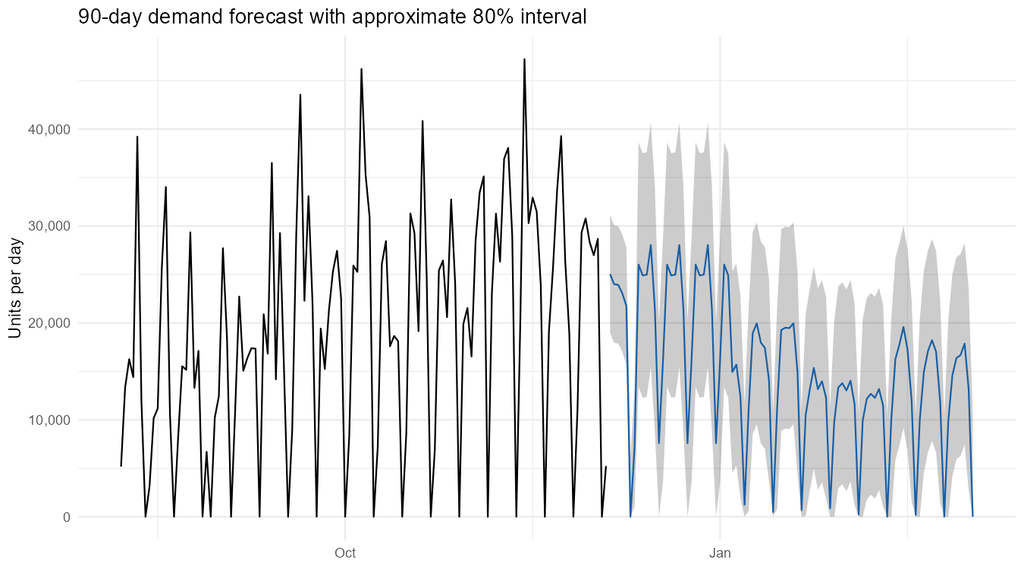

### Product Demand Classification

```
##
##  Product Demand Classes
##
##
## Table: Product Demand Classes
##
## |stock_code |description                 | units_prior90|predicted_demand |
## |:----------|:---------------------------|-------------:|:----------------|
## |10002      |INFLATABLE POLITICAL GLOBE  |             0|Low              |
## |10002R     |ROBOT PENCIL SHARPNER       |             0|Low              |
## |10080      |GROOVY CACTUS INFLATABLE    |           145|Medium           |
## |10109      |BENDY COLOUR PENCILS        |             0|Low              |
## |10120      |DOGGY RUBBER                |            66|Medium           |
## |10123C     |HEARTS WRAPPING TAPE        |             0|Low              |
## |10123G     |ARMY CAMO WRAPPING TAPE     |             0|Low              |
## |10124A     |SPOTS ON RED BOOKCOVER TAPE |             4|Medium           |
## |10124G     |ARMY CAMO BOOKCOVER TAPE    |             8|Low              |
## |10125      |MINI FUNKY DESIGN TAPES     |           309|High             |
```

```
##
##  Demand Classification
```

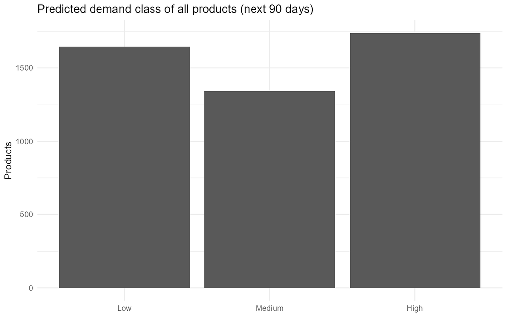

## 4.5 Key Findings

The project generates short-term and longer-term forecasts, compares forecasting models, and classifies product demand.

The model comparison results should be used to identify the most suitable model for each forecast horizon.

## 4.6 Business Implications

Demand forecasts can help managers plan purchasing, inventory replenishment, and stock availability.

## 4.7 Recommendations

- Use forecast results as planning support.
- Monitor forecast accuracy regularly.
- Compare predicted demand with actual sales.
- Review demand patterns before placing large orders.
- Update models when new sales data becomes available.

## 4.8 Limitations

- Forecast accuracy depends on historical data quality.
- Unexpected market changes may affect actual demand.
- Forecasts are estimates, not guaranteed sales results.

# Chapter 5: Anomaly Detection Report

## 5.1 Business Problem

Unusual sales patterns may indicate unexpected demand changes, transaction issues, or operational problems.

Anomaly detection helps managers identify unusual observations that require further investigation.

## 5.2 Dataset Description

This analysis uses cleaned retail transaction data and the anomaly detection outputs generated by the project.

## 5.3 Methodology

The workflow includes: - Data preparation. - Selection of relevant sales variables. - Anomaly identification. - Alert generation. - Visualization of unusual observations.

## 5.4 Analysis and Visualizations

### Anomaly Alerts

```
##
##  Detected Anomaly Alerts
##
##
## Table: Detected Anomaly Alerts
##
## |invoice_day |store_name        |category      | revenue| expected|    z|direction      |severity |confirmed_by_iqr |likely_cause                              |
## |:-----------|:-----------------|:-------------|-------:|--------:|----:|:--------------|:--------|:----------------|:-----------------------------------------|
## |2011-01-18  |Thrissur Central  |Uncategorised | 78275.7|   5790.2| 16.4|Unusually high |High     |TRUE             |Extreme order lines: check for data error |
## |2011-08-04  |Kottayam Main     |Uncategorised | 34041.4|   4336.1| 14.0|Unusually high |High     |TRUE             |Extreme order lines: check for data error |
## |2010-11-08  |Kottayam Main     |Uncategorised | 54723.5|   7211.9| 13.6|Unusually high |High     |TRUE             |Extreme order lines: check for data error |
## |2010-03-29  |Trivandrum City   |Uncategorised | 30056.3|   4860.2| 12.8|Unusually high |High     |TRUE             |Extreme order lines: check for data error |
## |2010-02-15  |Ernakulam Central |Uncategorised | 25285.8|   3607.3| 12.2|Unusually high |High     |TRUE             |Extreme order lines: check for data error |
## |2010-09-27  |Trivandrum City   |Uncategorised | 50149.6|   6426.9| 12.0|Unusually high |High     |TRUE             |Extreme order lines: check for data error |
## |2011-11-14  |Kottayam Main     |Uncategorised | 70809.9|   8425.2| 11.5|Unusually high |High     |TRUE             |Extreme order lines: check for data error |
## |2011-03-29  |Kozhikode Main    |Uncategorised | 23604.6|   2931.0| 11.0|Unusually high |High     |TRUE             |Extreme order lines: check for data error |
## |2011-09-20  |Thrissur Central  |Uncategorised | 31540.5|   5757.1| 10.5|Unusually high |High     |TRUE             |Extreme order lines: check for data error |
## |2010-07-15  |Trivandrum City   |Uncategorised | 33772.7|   5079.9| 10.2|Unusually high |High     |TRUE             |Extreme order lines: check for data error |
## |2011-11-07  |Thrissur Central  |Uncategorised | 58779.8|  10037.5|  8.6|Unusually high |High     |TRUE             |Extreme order lines: check for data error |
## |2011-06-10  |Ernakulam Central |Uncategorised | 44548.2|   6637.4|  8.3|Unusually high |High     |TRUE             |Extreme order lines: check for data error |
## |2011-06-09  |Kottayam Main     |Uncategorised | 22607.7|   5102.4|  7.7|Unusually high |High     |TRUE             |Extreme order lines: check for data error |
## |2011-09-20  |Ernakulam Central |Uncategorised | 46046.5|   7267.7|  7.6|Unusually high |High     |TRUE             |Extreme order lines: check for data error |
## |2011-08-11  |Thrissur Central  |Uncategorised | 34565.2|   6017.6|  7.5|Unusually high |High     |TRUE             |Extreme order lines: check for data error |
## |2011-03-29  |Thrissur Central  |Uncategorised | 24445.2|   4431.6|  7.4|Unusually high |High     |TRUE             |Extreme order lines: check for data error |
## |2011-02-15  |Kottayam Main     |Uncategorised | 23917.0|   4593.0|  7.3|Unusually high |High     |TRUE             |Unexplained: investigate                  |
## |2010-08-19  |Kottayam Main     |Uncategorised | 14514.5|   3860.2|  7.2|Unusually high |High     |TRUE             |Unexplained: investigate                  |
## |2010-08-09  |Thrissur Central  |Uncategorised | 17398.5|   4336.7|  6.9|Unusually high |High     |TRUE             |Extreme order lines: check for data error |
## |2010-07-09  |Kottayam Main     |Uncategorised | 20396.9|   4385.4|  6.8|Unusually high |High     |TRUE             |Extreme order lines: check for data error |
```

### Anomaly Visualization

```
##
##  Anomaly Detection Results
```

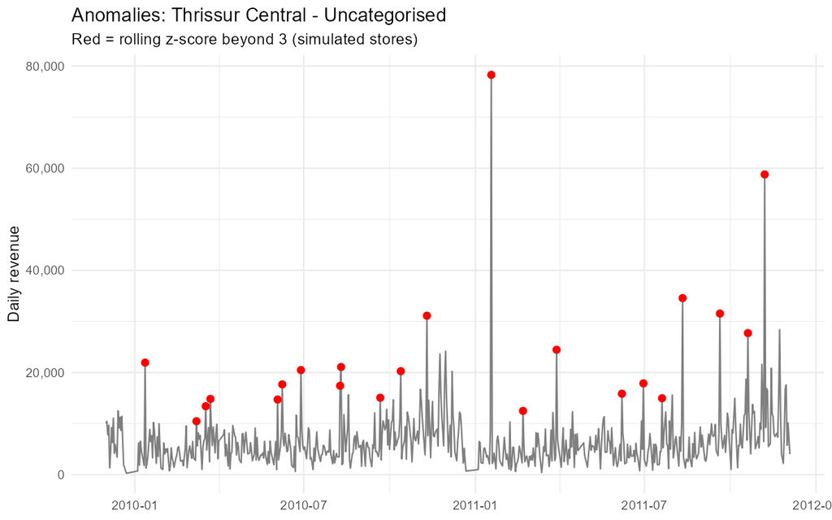

### Data Quality

```
##
##  Data Quality Report
##
##
## Table: Data Quality Report
##
## |metric                                    |   value|
## |:-----------------------------------------|-------:|
## |Raw rows                                  | 1048575|
## |Duplicate rows                            |   34150|
## |Rows with missing customer_id             |  236682|
## |Negative-quantity rows                    |   22697|
## |Zero/negative price rows                  |    6171|
## |Cancelled invoice rows                    |   19261|
## |Rejected rows                             |   45732|
## |Return rows                               |   17692|
## |Clean sales rows                          |  985151|
## |Share of raw rows kept as clean sales (%) |      94|
```

```
##
##  Data Rejection Reasons
##
##
## Table: Data Rejection Reasons
##
## |reject_reason                          |     n|
## |:--------------------------------------|-----:|
## |Duplicate row                          | 34150|
## |Non-product code (postage, fees, etc.) |  5599|
## |Zero or negative price                 |  5983|
```

## 5.5 Key Findings

The project produces anomaly alerts and visualizations to highlight unusual observations.

Each flagged observation should be reviewed before deciding whether it represents a genuine business issue.

## 5.6 Business Implications

Anomaly detection can support early investigation of unusual transaction patterns and help improve operational monitoring.

## 5.7 Recommendations

- Review flagged anomalies regularly.
- Investigate unusual revenue and quantity patterns.
- Check suspicious records against source transactions.
- Maintain data validation procedures.
- Record the reason for each investigated alert.

## 5.8 Limitations

- An anomaly is not necessarily an error or fraud.
- Detection depends on the selected method and thresholds.
- Unusual but genuine business events may also be flagged.

# Chapter 6: Final Business Recommendations Report

## 6.1 Business Problem

Retail managers need a consolidated view of sales, customers, inventory, demand, and unusual business patterns.

This chapter combines the project outputs into practical business recommendations.

## 6.2 Dataset Description

This report uses the cleaned sales dataset and the generated sales, customer, inventory, forecasting, and anomaly analysis outputs.

## 6.3 Methodology

The recommendations are based on: - Sales KPI analysis. - Customer segmentation and churn analysis. - Inventory risk analysis. - Demand forecasting. - Anomaly detection.

## 6.4 Analysis and Visualizations

### Business Recommendation Summary

```
##
##  Recommendation Summary
##
##
## Table: Recommendation Summary
##
## |type                |priority | recommendations| financial_impact_gbp|
## |:-------------------|:--------|---------------:|--------------------:|
## |Customer retention  |High     |              27|               180353|
## |Customer retention  |Medium   |              65|                82453|
## |Investigate returns |Medium   |            4731|                    0|
## |Reduce purchasing   |Low      |             168|                 2014|
## |Reduce purchasing   |Medium   |              42|                 2598|
## |Replenishment       |Critical |              17|                 1900|
## |Replenishment       |High     |              18|                 1454|
## |Replenishment       |Medium   |             129|                 3374|
## |Supplier review     |Medium   |               8|                    0|
```

```
##
##  Business Recommendations
##
##
## Table: Business Recommendations
##
## |rec_id   |rec_date   |type          |store_id |store_name        |entity_id |entity_name                        |situation     |recommendation                                                                                                                                                          …
## |:--------|:----------|:-------------|:--------|:-----------------|:---------|:----------------------------------|:-------------|:-----------------------------------------------------------------------------------------------------------------------------------------------------------------------…
## |REC-0001 |2011-12-04 |Replenishment |TSR01    |Thrissur Central  |22910     |PAPER CHAIN KIT VINTAGE CHRISTMAS  |Stock is zero |Order 645 units of PAPER CHAIN KIT VINTAGE CHRISTMAS for Thrissur Central. Forecast demand is 468 units over the next 28 days (lead time 14 + 14 review days); stock is …
## |REC-0002 |2011-12-04 |Replenishment |KTM01    |Kottayam Main     |85123A    |WHITE HANGING HEART T-LIGHT HOLDER |Stock is zero |Order 1269 units of WHITE HANGING HEART T-LIGHT HOLDER for Kottayam Main. Forecast demand is 682 units over the next 24 days (lead time 10 + 14 review days); stock is 0…
## |REC-0003 |2011-12-04 |Replenishment |EKM01    |Ernakulam Central |22960     |JAM MAKING SET WITH JARS           |Stock is zero |Order 152 units of JAM MAKING SET WITH JARS for Ernakulam Central. Forecast demand is 107 units over the next 29 days (lead time 15 + 14 review days); stock is 0, safet…
## |REC-0004 |2011-12-04 |Replenishment |EKM01    |Ernakulam Central |22178     |VICTORIAN GLASS HANGING T-LIGHT    |Stock is zero |Order 1124 units of VICTORIAN GLASS HANGING T-LIGHT for Ernakulam Central. Forecast demand is 548 units over the next 25 days (lead time 11 + 14 review days); stock is …
## |REC-0005 |2011-12-04 |Replenishment |TSR01    |Thrissur Central  |20713     |JUMBO BAG OWLS                     |Stock is zero |Order 310 units of JUMBO BAG OWLS for Thrissur Central. Forecast demand is 176 units over the next 22 days (lead time 8 + 14 review days); stock is 0, safety stock 133.…
## |REC-0006 |2011-12-04 |Replenishment |TSR01    |Thrissur Central  |22469     |HEART OF WICKER SMALL              |Stock is zero |Order 221 units of HEART OF WICKER SMALL for Thrissur Central. Forecast demand is 156 units over the next 24 days (lead time 10 + 14 review days); stock is 0, safety st…
## |REC-0007 |2011-12-04 |Replenishment |TSR01    |Thrissur Central  |22189     |CREAM HEART CARD HOLDER            |Stock is zero |Order 265 units of CREAM HEART CARD HOLDER for Thrissur Central. Forecast demand is 115 units over the next 29 days (lead time 15 + 14 review days); stock is 0, safety …
## |REC-0008 |2011-12-04 |Replenishment |KTM01    |Kottayam Main     |22385     |JUMBO BAG SPACEBOY DESIGN          |Stock is zero |Order 182 units of JUMBO BAG SPACEBOY DESIGN for Kottayam Main. Forecast demand is 116 units over the next 25 days (lead time 11 + 14 review days); stock is 0, safety s…
## |REC-0009 |2011-12-04 |Replenishment |KTM01    |Kottayam Main     |48194     |DOORMAT HEARTS                     |Stock is zero |Order 38 units of DOORMAT HEARTS for Kottayam Main. Forecast demand is 25 units over the next 19 days (lead time 5 + 14 review days); stock is 0, safety stock 13.      …
## |REC-0010 |2011-12-04 |Replenishment |KZD01    |Kozhikode Main    |21175     |GIN + TONIC DIET METAL SIGN        |Stock is zero |Order 230 units of GIN + TONIC DIET METAL SIGN for Kozhikode Main. Forecast demand is 117 units over the next 24 days (lead time 10 + 14 review days); stock is 0, safet…
```

```
##
##  Recommendations by Type
```

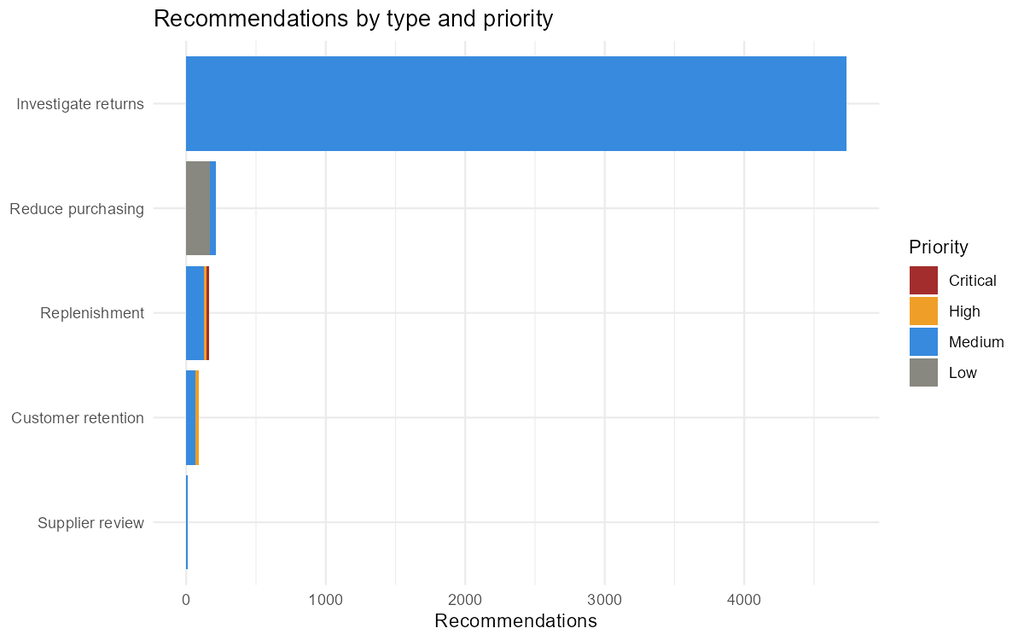

### Sales and Customer Performance

```
##
##  Sales KPI Summary
##
##
## Table: Sales KPI Summary
##
## | total_revenue| total_quantity| total_orders| avg_order_value|
## |-------------:|--------------:|------------:|---------------:|
## |      19148015|       10936372|        38975|        491.2897|
```

```
##
##  High-Value Customers
##
##
## Table: High-Value Customers
##
## | customer_id|segment   | recency| frequency| monetary|
## |-----------:|:---------|-------:|---------:|--------:|
## |       18102|Champions |       7|       142| 569501.5|
## |       14646|Champions |      12|       142| 515023.5|
## |       14156|Champions |       5|       144| 303069.9|
## |       14911|Champions |       4|       366| 266000.8|
## |       17450|Champions |       4|        51| 244784.2|
## |       13694|Champions |      21|       140| 192509.5|
## |       17511|Champions |      12|        58| 164753.5|
## |       12415|Champions |      20|        24| 144033.4|
## |       16684|Champions |       7|        54| 141740.8|
## |       15061|Champions |       6|       126| 122491.7|
```

### Inventory and Forecasting

```
##
##  Inventory KPI Summary
##
##
## Table: Inventory KPI Summary
##
## |metric                                         |    value|
## |:----------------------------------------------|--------:|
## |Current inventory value (GBP, simulated stock) | 424440.0|
## |Product-store combinations                     |    500.0|
## |Critical stockouts                             |     17.0|
## |Replenishment needed                           |    101.0|
## |Low stock (under 7 days)                       |     35.0|
## |Overstocked (over 90 days)                     |    115.0|
## |Slow-moving                                    |      2.0|
## |Dead stock                                     |      0.0|
## |Overall inventory turnover (times per year)    |      6.0|
## |Average days of inventory remaining (median)   |     57.9|
```

```
##
##  Forecast Model Comparison
##
##
## Table: Forecast Model Comparison
##
## |model  | horizon|     MAE|    RMSE|    Bias| MAPE| rmse_vs_snaive_pct|
## |:------|-------:|-------:|-------:|-------:|----:|------------------:|
## |naive  |       7|  7882.0| 10077.0|  7882.0| 32.5|              -59.0|
## |naive  |      30|  9202.2| 11932.6|  2899.9| 37.5|               -2.1|
## |naive  |      90|  9677.9| 12185.1|  1428.9| 39.8|               -7.1|
## |snaive |       7|  5151.1|  6336.5|  -211.7| 34.1|                0.0|
## |snaive |      30|  7611.8| 11690.9| -5414.3| 34.8|                0.0|
## |snaive |      90|  8112.7| 11375.3| -6754.7| 36.7|                0.0|
## |ma7    |       7|  4391.2|  6282.1|  -211.7| 14.7|                0.9|
## |ma7    |      30|  9923.8| 12686.7| -5193.8| 35.4|               -8.5|
## |ma7    |      90| 11925.0| 13815.0| -6664.8| 44.9|              -21.4|
## |ets    |       7|  3439.1|  5018.0| -1010.6| 21.7|               20.8|
```

## 6.5 Key Findings

The project provides analytical outputs across five important areas:

1. Sales performance and revenue trends.
2. Customer value and churn risk.
3. Inventory status and stock risk.
4. Demand forecasting and model evaluation.
5. Anomaly alerts and data quality.

These outputs provide a foundation for evidence-based retail decisions.

## 6.6 Business Implications

Combining the analytical results helps management understand how sales, customers, stock availability, and demand are connected.

## 6.7 Final Recommendations

- Monitor sales KPIs through regular dashboards.
- Develop targeted strategies for different customer groups.
- Improve inventory replenishment using demand forecasts.
- Review high-risk inventory items.
- Investigate unusual transaction patterns.
- Evaluate model performance regularly.
- Refresh datasets and reports periodically.

## 6.8 Limitations

- Findings depend on the quality and completeness of the available datasets.
- Forecasting and prediction models have uncertainty.
- Some cost and customer information may be incomplete.
- Recommendations should be reviewed alongside actual business conditions.

# Conclusion

Retail Pulse Kerala demonstrates how data analytics can support retail business decisions.

The project combines data cleaning, exploratory analysis, KPI calculation, customer analytics, inventory optimization, demand forecasting, anomaly detection, and business recommendations.

The final reports translate technical analysis into information that retail managers can use for planning and decision-making.